# Bayesian example

### Examine the chains and output

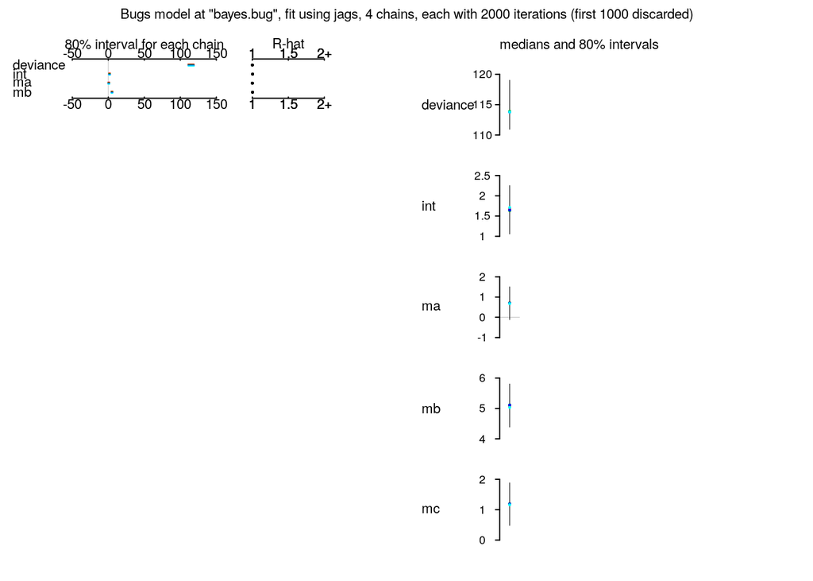

```r
bb <- jags1$BUGSoutput  ## extract the "BUGS output" component
mm <- as.mcmc.bugs(bb)  ## convert it to an "mcmc" object that coda can handle
plot(jags1)             ## large-format graph
```

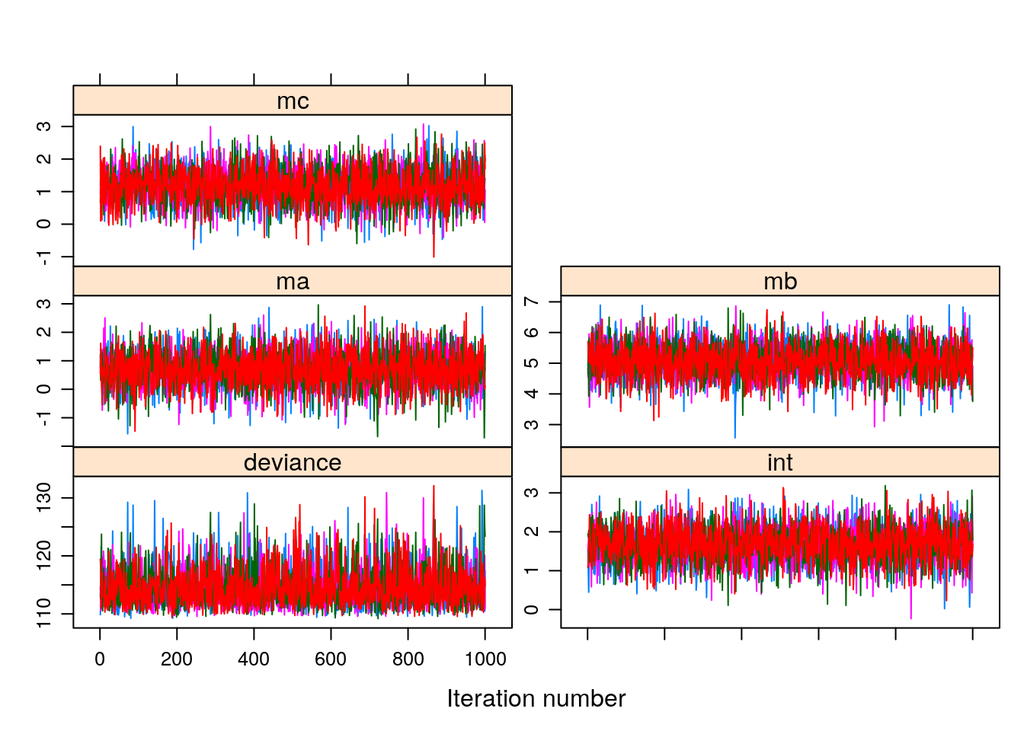

```r
## plot(mm)                ## trace + density plots, same as above
xyplot(mm,layout=c(2,3))  ## prettier trace plot
```

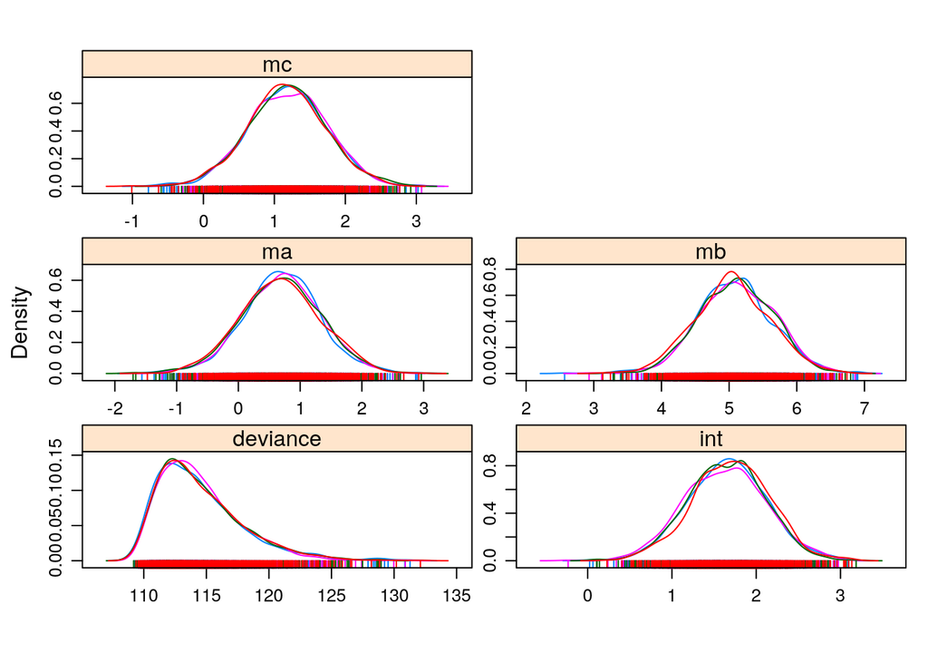

```r
densityplot(mm,layout=c(2,3)) ## prettier density plot
```

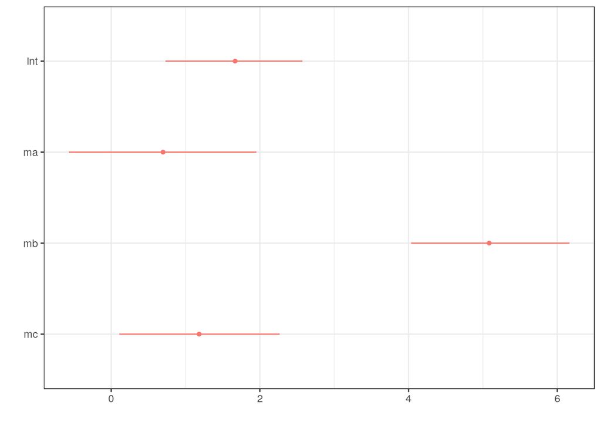

```r
print(dwplot(jags1))              ## estimate + credible interval plot
```

The `lump.mcmc.list` function from the `emdbook` package can be useful for converting a set of MCMC chains into a single long chain.

## Further notes

### Categorical variables

Implementing models with categorical variables (say, a t-test or an ANOVA) is a little bit more tedious than the multiple regression analysis shown above. There are two basic strategies:

- pass the categorical variable as a vector of numeric codes (i.e. pass `as.numeric(f)` rather than `f` to JAGS in your `data` list), and make your parameters a simple vector of the means corresponding to each level, e.g. you could have a vector of parameters `catparam` and specify the predicted value as `pred[i] = catparam[f[i]]`
- construct a design matrix using the `model.matrix` function in R and pass the whole model matrix (`X`) to JAGS. Then, to get the predicted value for each observation, just add up the relevant columns of the model matrix: e.g. `pred[i] = beta[1]*X[i,1]+beta[2]*X[i,2]+beta[3]*X[i,3]`. You can also use the built-in `inprod` (inner product) function: `pred[i] = inprod(X[i,],beta)`

The second approach is a little bit harder to understand but generalizes to more complicated situations, and gives you answers that will more closely match the analogous analyses in R (e.g. using `lm`).

### Built-in Bayesian modeling techniques

- `bayesglm` from the `arm` package

[output not shown]

```
## [1] 1
```

```
## [1] 1
```

```r
lms <- stan_lm(y~a+b+c,data=dat, prior=R2(0.2))
```

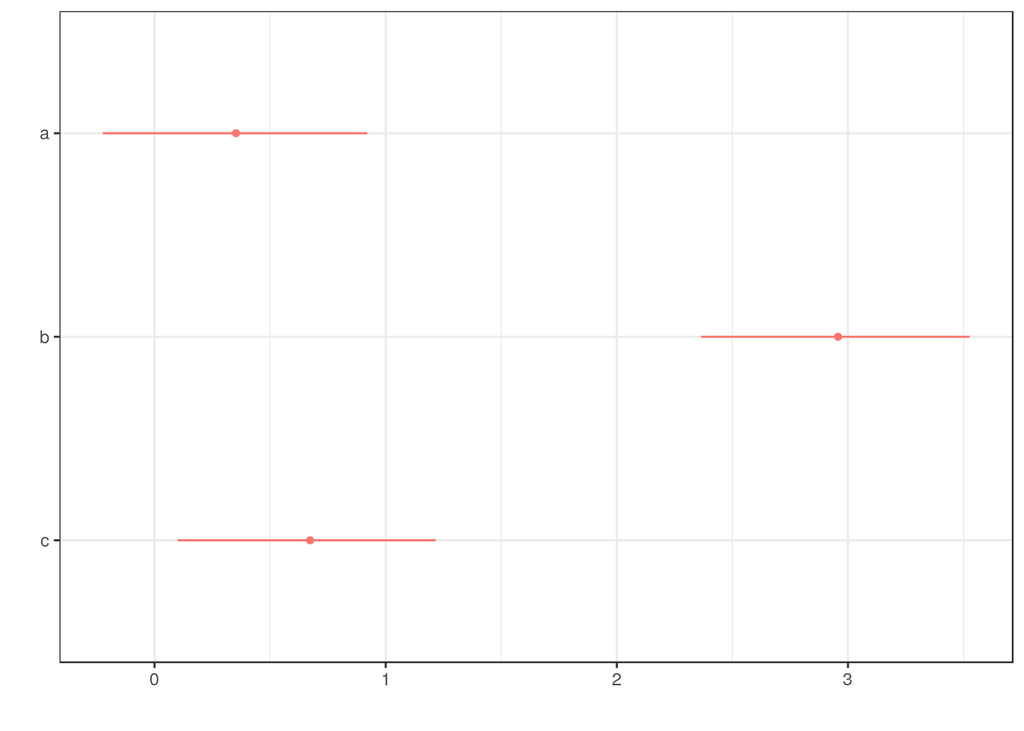

```r
dwplot(lms)
```

Similar to ‘lm’ or ‘aov’ but with novel regularizing priors on the model parameters that are driven by prior beliefs about R^2, the proportion of variance in the outcome attributable to the predictors in a linear model.